```
term_parser__term                     float64
emp_length_parser__emp_length         float64
target__loan_status                   float64
zip__zip_code                        category
pass__loan_amnt                       float64
pass__int_rate                        float64
pass__installment                     float64
pass__grade                          category
pass__sub_grade                      category
pass__home_ownership                 category
pass__annual_inc                      float64
pass__verification_status            category
pass__purpose                        category
pass__addr_state                     category
pass__dti                             float64
pass__delinq_2yrs                     float64
pass__fico_range_low                  float64
pass__fico_range_high                 float64
pass__inq_last_6mths                  float64
pass__mths_since_last_delinq          float64
pass__mths_since_last_record          float64
pass__open_acc                        float64
pass__pub_rec                         float64
pass__revol_bal                       float64
pass__revol_util                      float64
pass__total_acc                       float64
pass__initial_list_status            category
pass__last_fico_range_high            float64
pass__last_fico_range_low             float64
pass__collections_12_mths_ex_med      float64
pass__mths_since_last_major_derog     float64
pass__application_type               category
pass__annual_inc_joint                float64
pass__dti_joint                       float64
pass__verification_status_joint      category
pass__inq_fi                          float64
pass__inq_last_12m                    float64
pass__chargeoff_within_12_mths        float64
pass__mort_acc                        float64
pass__pub_rec_bankruptcies            float64
pass__tax_liens                       float64
pass__tot_hi_cred_lim                 float64
pass__total_bal_ex_mort               float64
dtype: object
```

# 2.1.1 Training and Testing the Default Risk Model

The dataset is pre-split into a 20% test sample and a 80% training sample (10% of which is used for tuning):

```
Total Samples Loaded 1210204
```

[output not shown]

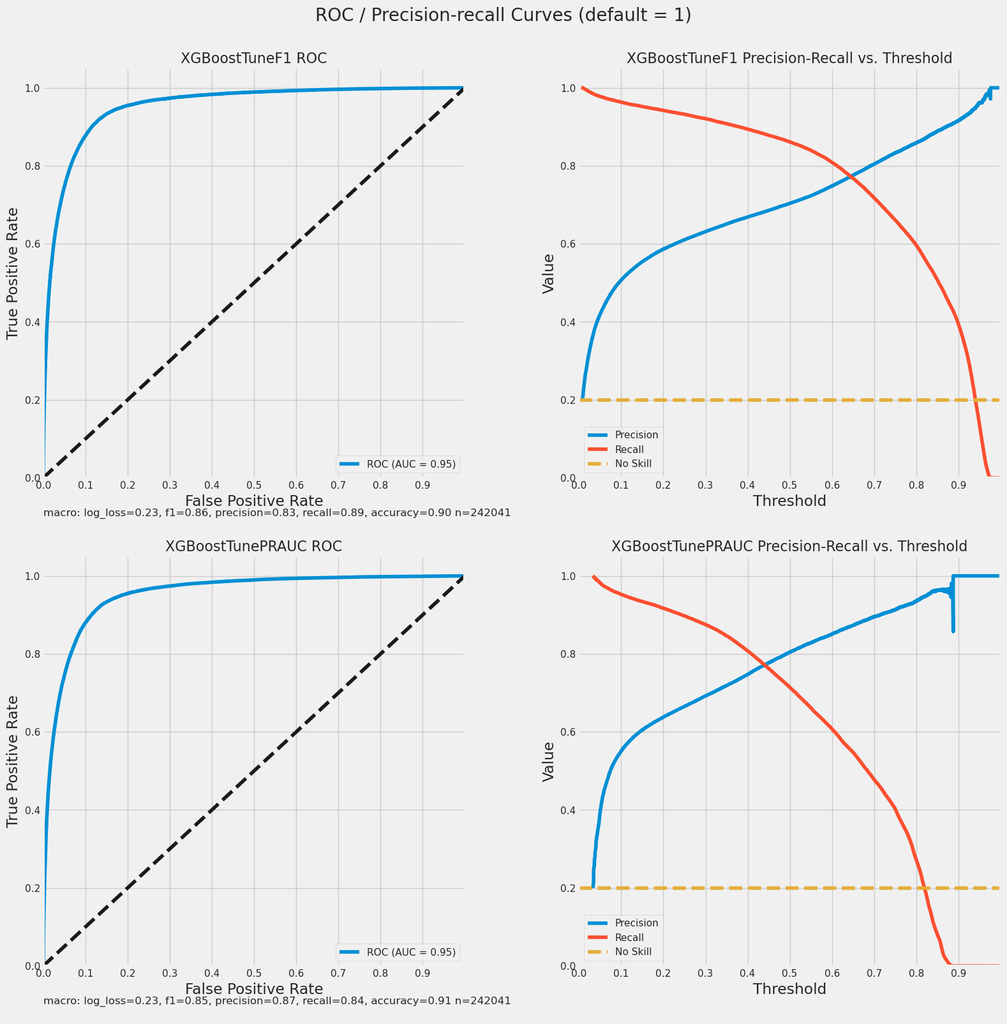

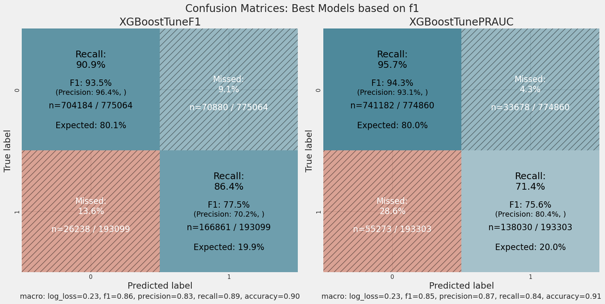

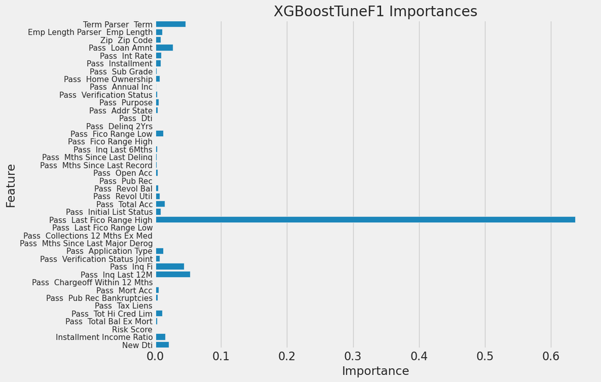

|  | Feature | Importance |
| --- | --- | --- |
| 0 | term_parser__term | 0.046249 |
| 1 | emp_length_parser__emp_length | 0.010484 |
| 2 | zip__zip_code | 0.008205 |
| 3 | pass__loan_amnt | 0.026461 |
| 4 | pass__int_rate | 0.009085 |
| 5 | pass__installment | 0.008085 |
| 6 | pass__sub_grade | 0.002424 |
| 7 | pass__home_ownership | 0.006691 |
| 8 | pass__annual_inc | 0.001189 |
| 9 | pass__verification_status | 0.002817 |
| 10 | pass__purpose | 0.005181 |
| 11 | pass__addr_state | 0.003578 |
| 12 | pass__dti | 0.000481 |
| 13 | pass__delinq_2yrs | 0.000000 |
| 14 | pass__fico_range_low | 0.012209 |
| 15 | pass__fico_range_high | 0.000000 |
| 16 | pass__inq_last_6mths | 0.003078 |
| 17 | pass__mths_since_last_delinq | 0.002028 |
| 18 | pass__mths_since_last_record | 0.002129 |
| 19 | pass__open_acc | 0.003595 |
| 20 | pass__pub_rec | 0.000000 |
| 21 | pass__revol_bal | 0.004596 |
| 22 | pass__revol_util | 0.006599 |
| 23 | pass__total_acc | 0.014794 |
| 24 | pass__initial_list_status | 0.008644 |
| 25 | pass__last_fico_range_high | 0.636663 |
| 26 | pass__last_fico_range_low | 0.000000 |
| 27 | pass__collections_12_mths_ex_med | 0.000082 |
| 28 | pass__mths_since_last_major_derog | 0.000075 |
| 29 | pass__application_type | 0.012244 |
| 30 | pass__verification_status_joint | 0.006884 |
| 31 | pass__inq_fi | 0.043678 |
| 32 | pass__inq_last_12m | 0.052992 |
| 33 | pass__chargeoff_within_12_mths | 0.000000 |
| 34 | pass__mort_acc | 0.005532 |
| 35 | pass__pub_rec_bankruptcies | 0.003598 |
| 36 | pass__tax_liens | 0.000000 |
| 37 | pass__tot_hi_cred_lim | 0.010544 |
| 38 | pass__total_bal_ex_mort | 0.003171 |
| 39 | risk_score | 0.000000 |
| 40 | installment_income_ratio | 0.015156 |
| 41 | new_dti | 0.020779 |

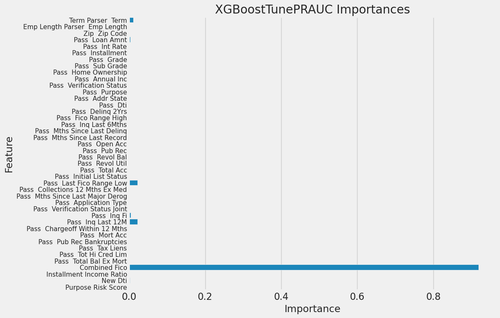

|  | Feature | Importance |
| --- | --- | --- |
| 0 | term_parser__term | 0.011087 |
| 1 | emp_length_parser__emp_length | 0.001202 |
| 2 | zip__zip_code | 0.001174 |
| 3 | pass__loan_amnt | 0.002792 |
| 4 | pass__int_rate | 0.000528 |
| 5 | pass__installment | 0.001426 |
| 6 | pass__grade | 0.000395 |
| 7 | pass__sub_grade | 0.000258 |
| 8 | pass__home_ownership | 0.000333 |
| 9 | pass__annual_inc | 0.000163 |
| 10 | pass__verification_status | 0.000701 |
| 11 | pass__purpose | 0.000238 |
| 12 | pass__addr_state | 0.000407 |
| 13 | pass__dti | 0.000190 |
| 14 | pass__delinq_2yrs | 0.000097 |
| 15 | pass__fico_range_high | 0.000731 |
| 16 | pass__inq_last_6mths | 0.000203 |
| 17 | pass__mths_since_last_delinq | 0.000310 |
| 18 | pass__mths_since_last_record | 0.000123 |
| 19 | pass__open_acc | 0.000204 |
| 20 | pass__pub_rec | 0.000000 |
| 21 | pass__revol_bal | 0.000212 |
| 22 | pass__revol_util | 0.000378 |
| 23 | pass__total_acc | 0.000977 |
| 24 | pass__initial_list_status | 0.001008 |
| 25 | pass__last_fico_range_low | 0.022224 |
| 26 | pass__collections_12_mths_ex_med | 0.000000 |
| 27 | pass__mths_since_last_major_derog | 0.000188 |
| 28 | pass__application_type | 0.000789 |
| 29 | pass__verification_status_joint | 0.000675 |
| 30 | pass__inq_fi | 0.004502 |
| 31 | pass__inq_last_12m | 0.021451 |
| 32 | pass__chargeoff_within_12_mths | 0.000000 |
| 33 | pass__mort_acc | 0.000646 |
| 34 | pass__pub_rec_bankruptcies | 0.001127 |
| 35 | pass__tax_liens | 0.000000 |
| 36 | pass__tot_hi_cred_lim | 0.001025 |
| 37 | pass__total_bal_ex_mort | 0.000277 |
| 38 | combined_fico | 0.918560 |
| 39 | installment_income_ratio | 0.001464 |
| 40 | new_dti | 0.001635 |
| 41 | purpose_risk_score | 0.000299 |

#### Analyzing and Predicting Grades

##### Average Default Rate by Grade in the Dataset:

|  | Counts | Proportion | Loan_Status_Ratio |
| --- | --- | --- | --- |
| A | 211381 | 0.174666 | 0.060445 |
| B | 353495 | 0.292095 | 0.134030 |
| C | 343327 | 0.283693 | 0.224480 |
| D | 180840 | 0.149429 | 0.303639 |
| E | 84224 | 0.069595 | 0.384214 |
| F | 28719 | 0.023731 | 0.451165 |
| G | 8218 | 0.006791 | 0.501582 |

### Evaluating Financial Returns/Performance

We'll use the model we have built to narrow down the sample of loans that have a lower risk to default.

This would be more useful to potential investors rather than the Lenders Club itself, they can use it in addition to the grade and other data provided by the Lenders Club to select the loans which not to invest it in.

The table below shows the total returns of all the loans in the dataset. We have to note that this is highly simplified because it assumes that all the loans that were defaulted on had to be completely written off but realistically this is not really the case:

- all lenders are likely to make at least some payments before they default
- defaulted loans can still be sold to third part for a fraction of the owed amount In future version of our model we should take these factors into account.

|  | Total Loan Amount | Total Interest Paid | Expected Return % | Total Return % | Total Loss |
| --- | --- | --- | --- | --- | --- |
| 0 | 17451.88m | 1770.28m | 13.645651 | 10.143752 | 3757.82m |

We have selected only the loans which are unlikely to default using the default 50% threshold (note that the predicted probabilities don't directly indicate the likelihood of default):

|  | Actual | Hypothetical |
| --- | --- | --- |
| Total Loan Amount | 17451.8813M | 2804.2057M |
| Total Interest Paid | 1770.2756M | 362.0434M |
| Total Return % | 10.14% | 12.91% |
| Default Rate | 19.96% | 6.93% |
| Total Loss | 3757.8181M | 189.3224M |
| Losses Avoided | None | 3568.4957M |
| Interest Lost | None | -1408.2322M |
| Total Applications Accepted | 1210204 | 199192 |

Our model is fairly conservative and has rejected most of the loans offered by the Lenders Club (i.e. more than 80% are considered to be too risky). This would make it not very useful for the Lenders Club itself (however we might be able to improve this tuning the threshold). However, from the perspective of potential investors this is perfectly acceptable because they are likely to only invest into a small subset of available loans.

Using our model would allow investors to signficantly improve their returns by 3% or so, further improvements might be possible by improving the threshold (we'll look into this in the next section).

### Calculating Probability Thresholds

If we're using our binary classification model to assign grades to loans based on default probabilities we can't directly try to predict the grades from the source dataset.

Basically what we can do is to use the source dataset as a baseline and try to determine whether our model can outperform the method the Lending Club is using for determine grades, we'll try to maintain the same ratio of grades while trying to minimize the default risk for loans included in top grades (basically we want to make sure that's the spread of default risk between grades is maximized i.e. default risk for grade A is as close to 0% and for grade F as close to 100% as possible while also ensuring that the risk increased with continuously with grade)

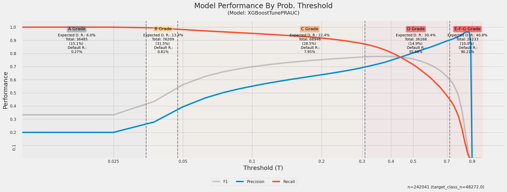

We have used the predicted probabilities to suggest alternative grades for each loan. `Expected D.R` is the default rate based on original grades. We can see our grades are much better at excluding higher risk loans from higher grades.

Generally this does not necessarily mean that source grades are inaccurate or objectively worse, the investors club is likely using a more straightforward and transparent algorithm for assigning them and investors should be using additional criteria when selecting which loans to invest anyway.

#### Comparing Interest Rates for Predicted Grades

In this section we'll try to evaluate investment strategies that are entirely based on loan grades (either the original ones or ones provided by our model)

#### Predicted Grade Real Return Rates

```
'Returns and Default Rate by Grade in Source Dataset:'
```

| pass__grade_merged | default_rate | mean_interest_rate | expected_return |
| --- | --- | --- | --- |
| A | 0.06 | 7.11 | 6.69 |
| B | 0.13 | 10.68 | 9.26 |
| C | 0.22 | 14.02 | 10.87 |
| D | 0.30 | 17.73 | 12.36 |
| E-F-G | 0.41 | 22.51 | 13.27 |

```
'Returns and Default Rate Based on Default Probability Model:'
```

| predicted_grades | default_rate | mean_interest_rate | expected_return |
| --- | --- | --- | --- |
| A | 0.003 | 10.353 | 10.325 |
| B | 0.008 | 12.197 | 12.098 |
| C | 0.080 | 13.853 | 12.751 |
| D | 0.559 | 14.750 | 6.508 |
| E-F-G | 0.902 | 16.902 | 1.655 |

We can see that while using our model to invested in the worst grades loans would lead to relatively poor returns investing in only in `C` grade or higher rated loans would provide better returns than using the Lenders Club's values to invest in the same loans:

- Investing only in `C` loans would provide almost the same returns as the far riskier `E-F-G` loans using the original grades.
- Only investing in `A` loans still yields ~10%, considering that the default rate is extremely low it might still be a preferable option to investing into high risk loans.

Basically using our model the investor would be able to minimize default risk while still getting decent returns i.e. if they only invested in loans with an estimated 10% default likelyhood or less using the original grades (so only `A` grade loans) they'd only make 6-7% while using our model this can be increased to more than 10%.

### Limitations

Therefore, to provide a more accurate estimate and to figure out whether our model would actually be useful we'd need to incorporate the actual amounts received etc.